# blog

2026-03-04

## Goal

Simulate a cointegrated relationship between air temperature (driver) and ground temperature (response) across five sensors. Air temperature time series are different for each sensor (local variability and seasonality), and ground logs have missing values that vary by sensor to mimic faulty data loggers. The simulation follows a VECM-style error-correction process so that ground temperature tracks a long-run equilibrium with air, while short-run changes in air also affect ground.

## How The Simulation Works

- Air process (`A_{t,i}`): per-sensor integrated AR(1) with mild seasonality and sensor-specific variance/AR parameter; air varies more than ground and differs by location.
- Long-run equilibrium: `G_t` tends to `c_i + beta * A_t` with `beta < 1` so the ground amplitude is lower than air.
- Error correction: deviation `z_{t-1} = G_{t-1} - beta * A_{t-1} - c_i` is pulled back by `alpha_i < 0` (slower correction).
- Lagged short-run: ground responds to past air changes, `ΔA_{t-L}` (we use L = 7 days), making ground move sluggishly.
- Heterogeneity: sensor-level random effects for `alpha_i`, `gamma_i`, and `c_i`.
- Missingness: only ground logs are missing; each sensor gets its own missing rate, with block gaps added for the worst loggers.

The data and plot are created in `script.R`.

```r
source("script.R")
```

### Missingness By Sensor

Share of missing ground observations by sensor

| sensor | miss_rate |
| --- | --- |
| S1 | 0.05 |
| S2 | 0.09 |
| S3 | 0.29 |
| S4 | 0.58 |
| S5 | 0.83 |

## Visual Check

The plot below shows complete air (blue) and observed ground (red) per sensor. Ground has lower amplitude, higher inertia, and lags behind air; better sensors have fewer gaps.

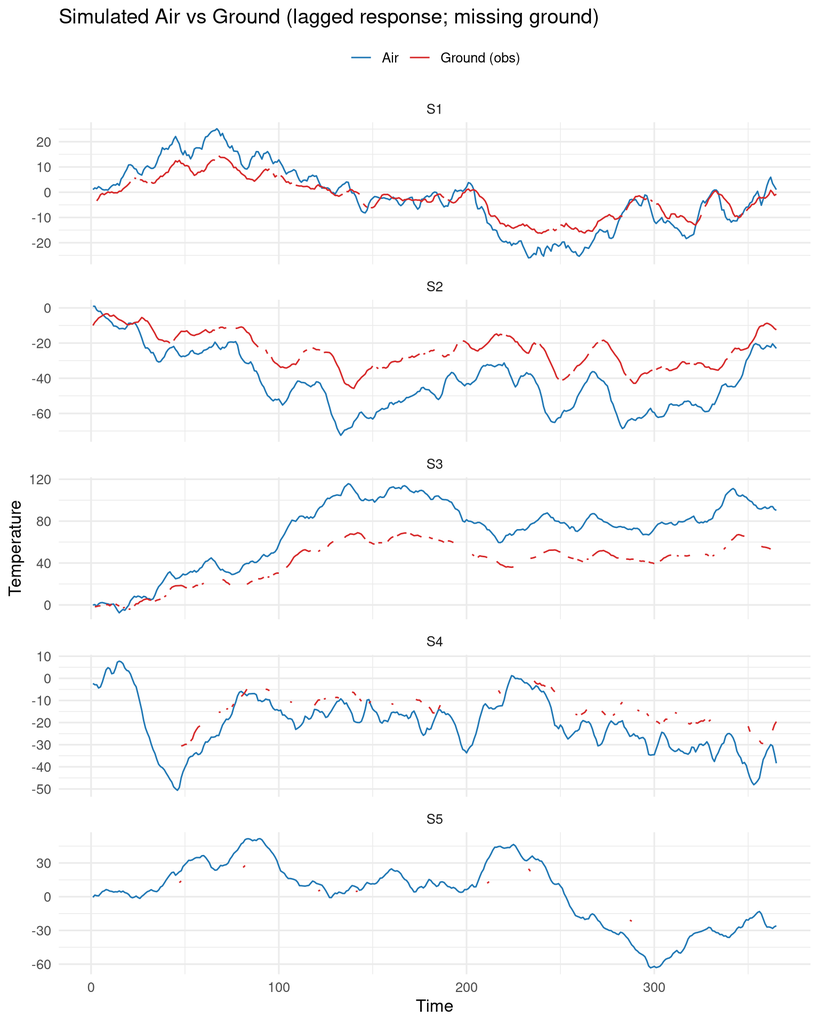

## Stan Model (Imputation)

We fit a hierarchical error-correction (VECM-style) state-space model in Stan to impute missing ground temperatures and quantify uncertainty. Air temperature is treated as a known covariate.

### Model Specification

Let sensors `i = 1, ..., S` and times `t = 1, ..., T`. Air temperature is `A_t` and its change is `\Delta A_t = A_t - A_{t-1}`.

- Cointegrating equilibrium per sensor:

$$G^*_{t,i} = c_i + (\beta_0 +
\beta_i)\,A_t$$

- Error-correction term:

$$z_{t-1,i} = G_{t-1,i} - (\beta_0 +
\beta_i)\,A_{t-1} - c_i$$

- State evolution (short-run dynamics are contemporaneous in the Stan model):

$$G_{t,i} = G_{t-1,i} +
\alpha_i\,z_{t-1,i} + \gamma_i\,\Delta A_t +
\varepsilon_{t,i}$$

equivalently

$$\Delta G_{t,i} = \alpha_i\,z_{t-1,i} +
\gamma_i\,\Delta A_t + \varepsilon_{t,i},\quad \varepsilon_{t,i} \sim
\mathcal{N}(0,\sigma_{\text{eps}})$$

- Initial state prior (sub-zero starts):

$$G_{1,i} \sim
\mathcal{N}(\mu^{(G1)}_i,\,\sigma_{\text{init}}),\quad \mu^{(G1)}_i \sim
\mathcal{N}(-5,\,3)$$

- Hierarchical priors for sensor effects and hyperparameters:

$$\alpha_i \sim
\mathcal{N}(\mu_\alpha,\,\sigma_\alpha),\qquad \gamma_i \sim
\mathcal{N}(\mu_\gamma,\,\sigma_\gamma),\qquad c_i \sim
\mathcal{N}(\mu_c,\,\sigma_c)$$

$$\mu_\alpha \sim
\mathcal{N}(-0.3,0.3),\quad \mu_\gamma \sim \mathcal{N}(0.6,0.3),\quad
\mu_c \sim \mathcal{N}(0,2)$$

Partial pooling for cointegration slope:

$$\beta_0 \sim \mathcal{N}(0.8,0.2),\qquad
\beta_i \sim \mathcal{N}(0,\,\sigma_\beta),\qquad \sigma_\beta \sim
\text{Exponential}(1)$$

$$\sigma_\alpha,\sigma_\gamma,\sigma_c,\sigma_{\text{init}},\sigma_{\text{eps}},\sigma_{\text{obs}}
\sim \text{Exponential}(1)$$

- Observation model (known indexes `(t_n, i_n)` for observed entries `n = 1, ..., N_{\text{obs}}`):

$$y^{\text{obs}}_n \sim
\mathcal{N}(\,G_{t_n,i_n},\,\sigma_{\text{obs}}\,)$$

- Missing data (Stan slicing; unknowns `y^{\text{mis}}_m` for missing indexes `(\tau_m, j_m)`, `m = 1, ..., N_{\text{mis}}`):

$$y^{\text{mis}}_m \sim
\mathcal{N}(\,G_{\tau_m,j_m},\,\sigma_{\text{obs}}\,)$$

This follows Stan’s recommended pattern: observed and missing outcomes are split and modeled separately, with missing outcomes declared as parameters. Air `A_t` and `\Delta A_t` are treated as known covariates.

Note: Our simulation uses a 7-day lag for short-run effects (`\Delta A_{t-7,i}`) to make ground respond more slowly. The Stan fit uses contemporaneous `\Delta A_{t,i}`; swapping to a lagged `\Delta A_{t-L,i}` is straightforward.

```r
library(cmdstanr)
library(dplyr)
library(tidyr)
library(stringr)

# prepare indices for observations
sensors <- unique(sim$sensor)
sensor_index <- setNames(seq_along(sensors), sensors)

T_ <- max(sim$t)
S_ <- length(sensors)

# build T x S matrices for air and its change (per sensor)
air_wide <- sim %>% select(t, sensor, air) %>% tidyr::pivot_wider(names_from = sensor, values_from = air) %>% arrange(t)
dA_wide  <- sim %>% select(t, sensor, dA)  %>% tidyr::pivot_wider(names_from = sensor, values_from = dA)  %>% arrange(t)

A_mat <- as.matrix(air_wide[ , setdiff(names(air_wide), "t")])
dA_mat <- as.matrix(dA_wide[ , setdiff(names(dA_wide), "t")])

obs_df <- sim %>%
  filter(!is.na(ground_obs)) %>%
  mutate(i = sensor_index[sensor]) %>%
  select(t, i, y = ground_obs) %>%
  arrange(i, t)

mis_df <- sim %>%
  filter(is.na(ground_obs)) %>%
  mutate(i = sensor_index[sensor]) %>%
  select(t, i) %>%
  arrange(i, t)

stan_data <- list(
  T = T_, S = S_, A = A_mat, dA = dA_mat,
  N_obs = nrow(obs_df),
  obs_t = obs_df$t,
  obs_i = obs_df$i,
  y_obs = obs_df$y,
  N_mis = nrow(mis_df),
  mis_t = if (nrow(mis_df) > 0) mis_df$t else integer(0),
  mis_i = if (nrow(mis_df) > 0) mis_df$i else integer(0)
)

mod <- cmdstan_model("vecm_partial_pooling.stan")
fit <- mod$sample(
  data = stan_data,
  seed = 100,

  chains = 1, parallel_chains = 4,
  iter_warmup = 800, iter_sampling = 800,
  adapt_delta = 0.9
)

# summarize latent ground G[t,i]
sum_G <- fit$summary(variables = c("G"))
sum_G <- sum_G %>%
  select(variable, mean, sd) %>%
  mutate(idx = str_match(variable, "G\\[(\\d+),(\\d+)\\]")) %>%
  mutate(t = as.integer(idx[,2]), i = as.integer(idx[,3])) %>%
  select(t, i, ground_mean = mean, ground_sd = sd)

imputed <- tidyr::expand_grid(t = 1:T_, i = 1:S_) %>%
  left_join(sum_G, by = c("t","i")) %>%
  mutate(sensor = names(sensor_index)[i]) %>%
  select(t, sensor, ground_mean, ground_sd)
```

### Plot With Imputations

The plot overlays the posterior mean ground temperature and highlights uncertainty (±2 SD) at time points where ground data were missing.

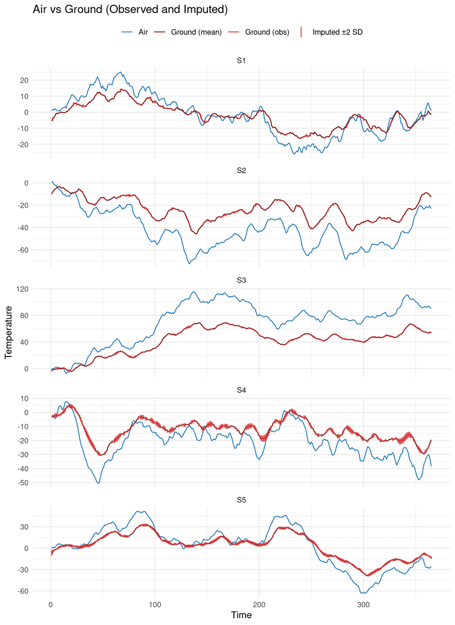

## Notes

- Sensors start below 0°C in the simulation; the Stan model also places a prior for sub-zero initial states.
- Missing data are handled per Stan’s recommendations by separating observed and missing indices and introducing `y_mis` as parameters linked to the latent state.
- The tibble `sim` has: `t`, `sensor`, `air`, `dA`, `ground_true`, `ground_obs`. The `imputed` tibble adds `ground_mean`, `ground_sd` from the posterior.